# A Shallow Dive into Time Series: Analysis of Local Restaurant Data Using R

Now for p:

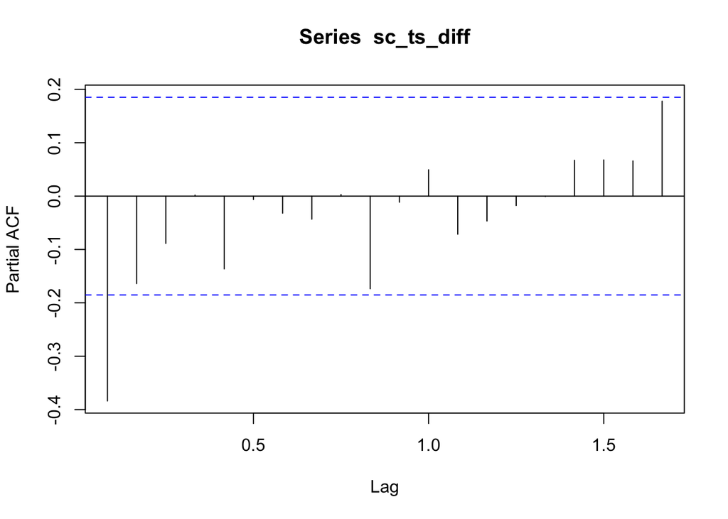

```r
# Instead of acf() we use pacf() to find partial autocorrelation.
plot(pacf(sc_ts_diff, na.action = na.pass))
```

Here, the partial auto correlation function returns a negative tail. This is suggestive that the time series data needs extra differencing. You can continue on to do things like difference the mean, use a Box-Cox Transformation, or any number of other methods, but here I will choose to use the auto.arima function to aid in the forecasting. This function comes from the forecast package so we will need to call its library.

```r
library(forecast)
auto.arima(sc_ts_na_rm)
```

```
## Series: sc_ts_na_rm
## ARIMA(1,1,1) with drift
##
## Coefficients:
##          ar1      ma1   drift
##       0.2388  -0.9275  2.4009
## s.e.  0.1099   0.0496  0.6545
##
## sigma^2 estimated as 4170:  log likelihood=-624.96
## AIC=1257.93   AICc=1258.3   BIC=1268.8
```

Now we can see how R estimated the AR, I, and MA values. This is a handy function, and Using the information given by the auto.arima function we can now attempt to plot a forecast for restaurant popularity using this information as a guide.

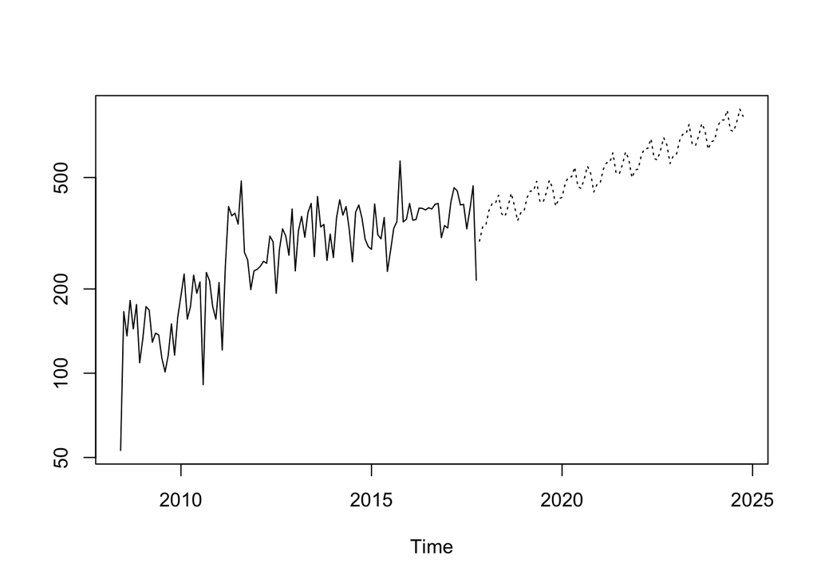

```r
sc_ts_fitted <- arima(log(sc_ts_na_rm), c(1, 1, 1), seasonal = list(order = c(1, 1, 1), period = 12))

# How far to predict into the future
pred <- predict(sc_ts_fitted, n.ahead = 7*12)

# The code below accounts for the fact that we took the log earlier
ts.plot(sc_ts_na_rm, 2.718^pred$pred, log = "y", lty = c(1, 3))
```

This is good, and it seems to make sense but I want to try another procedure. At this point I’ll decide to move on to a decomposition of the time series data to get a better overall idea of what is happening. Use a `decomposition()` function to view the different features of the time series. This will show us the original observed data plotted over time, the trend line, the seasonality, and random factors (ie things out of control like road work that might limit the number of guests to the restaurant during a particuar month).

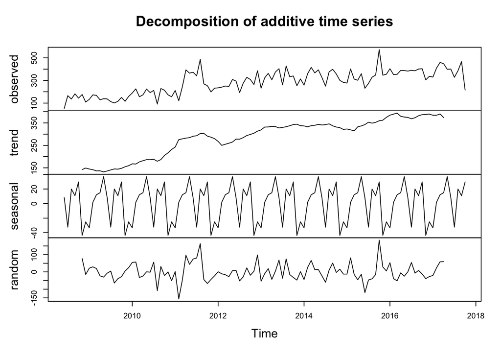

```r
# Attain the decomposition of the additive time series by using the decompose()
# function and then plotting the result
dec_sc_ts <- decompose(sc_ts_na_rm)
plot(dec_sc_ts)
```

Now that we can see the different components to our time series data, we can also start to consider forcasting with the decomposition as well.This requires the use of the `stl()` function from the ‘forecast’ package.